# Analyses of Variance (ANOVA), Part 2

Adam Raikes

March 13, 2017

# Purpose

The purpose of this slideshow is to continue our discussion of ANOVAs. The emphasis here will be on evaluating assumptions of normality and homoscedasticity (equal group variances).

# How does this look

We’re going to use data from a publicly available health survey dataset.

```
## # A tibble: 6 × 76
##      ID SurveyYr Gender   Age AgeDecade AgeMonths  Race1  Race3
##   <int>   <fctr> <fctr> <int>    <fctr>     <int> <fctr> <fctr>
## 1 51624  2009_10   male    34     30-39       409  White     NA
## 2 51624  2009_10   male    34     30-39       409  White     NA
## 3 51624  2009_10   male    34     30-39       409  White     NA
## 4 51625  2009_10   male     4       0-9        49  Other     NA
## 5 51630  2009_10 female    49     40-49       596  White     NA
## 6 51638  2009_10   male     9       0-9       115  White     NA
## # ... with 68 more variables: Education <fctr>, MaritalStatus <fctr>,
## #   HHIncome <fctr>, HHIncomeMid <int>, Poverty <dbl>, HomeRooms <int>,
## #   HomeOwn <fctr>, Work <fctr>, Weight <dbl>, Length <dbl>,
## #   HeadCirc <dbl>, Height <dbl>, BMI <dbl>, BMICatUnder20yrs <fctr>,
## #   BMI_WHO <fctr>, Pulse <int>, BPSysAve <int>, BPDiaAve <int>,
## #   BPSys1 <int>, BPDia1 <int>, BPSys2 <int>, BPDia2 <int>, BPSys3 <int>,
## #   BPDia3 <int>, Testosterone <dbl>, DirectChol <dbl>, TotChol <dbl>,
## #   UrineVol1 <int>, UrineFlow1 <dbl>, UrineVol2 <int>, UrineFlow2 <dbl>,
## #   Diabetes <fctr>, DiabetesAge <int>, HealthGen <fctr>,
## #   DaysPhysHlthBad <int>, DaysMentHlthBad <int>, LittleInterest <fctr>,
## #   Depressed <fctr>, nPregnancies <int>, nBabies <int>, Age1stBaby <int>,
## #   SleepHrsNight <int>, SleepTrouble <fctr>, PhysActive <fctr>,
## #   PhysActiveDays <int>, TVHrsDay <fctr>, CompHrsDay <fctr>,
## #   TVHrsDayChild <int>, CompHrsDayChild <int>, Alcohol12PlusYr <fctr>,
## #   AlcoholDay <int>, AlcoholYear <int>, SmokeNow <fctr>, Smoke100 <fctr>,
## #   Smoke100n <fctr>, SmokeAge <int>, Marijuana <fctr>,
## #   AgeFirstMarij <int>, RegularMarij <fctr>, AgeRegMarij <int>,
## #   HardDrugs <fctr>, SexEver <fctr>, SexAge <int>, SexNumPartnLife <int>,
## #   SexNumPartYear <int>, SameSex <fctr>, SexOrientation <fctr>,
## #   PregnantNow <fctr>
```

# Gender, Race, and BMI

So we are going to look at weight between genders and races.

```r
table(NHANES$Gender, NHANES$Race1)
```

```
##
##          Black Hispanic Mexican White Other
##   female   614      320     452  3221   413
##   male     583      290     563  3151   393
```

# Gender, Race, and BMI

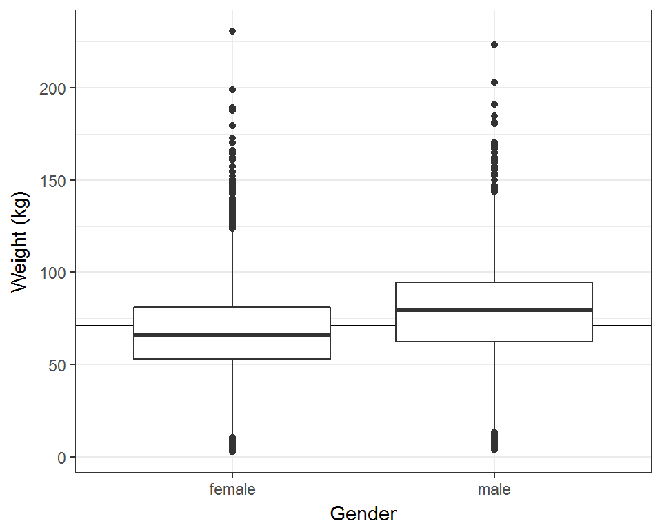

# Gender, Race, and BMI

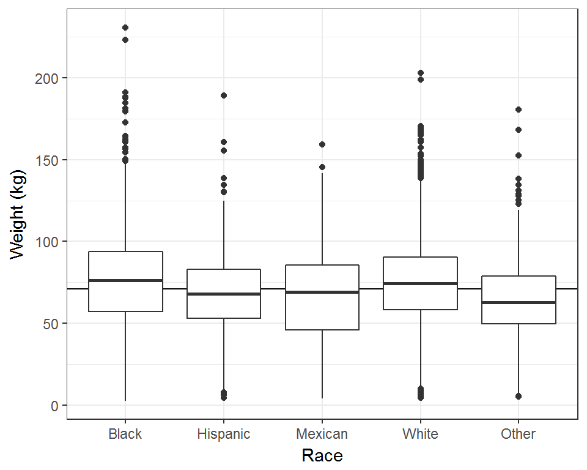

# Gender, Race, and BMI

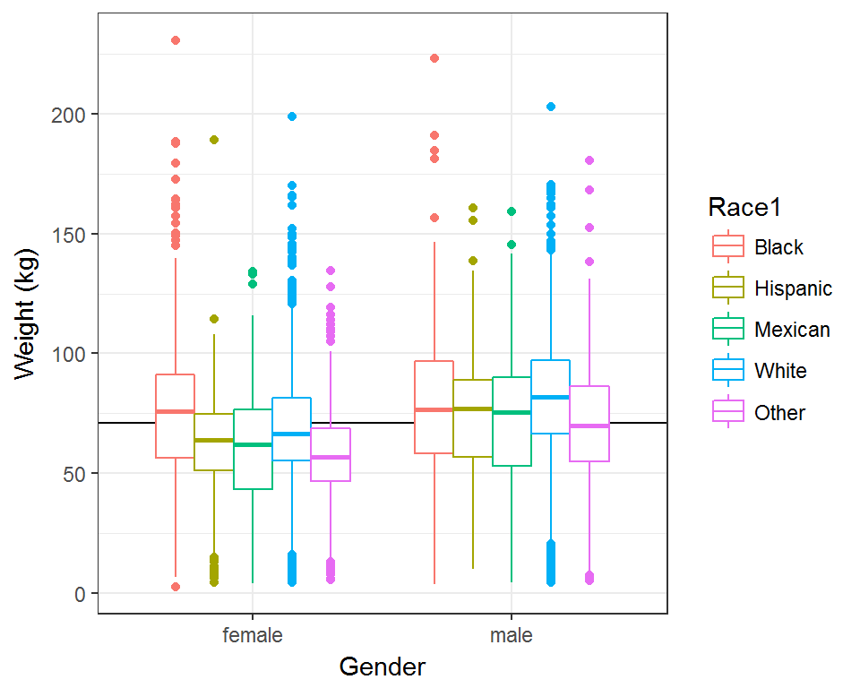

# Gender, Race, and BMI

There are multiple levels of Race in the dataset. Therefore, we cannot easily use a t-test. An ANOVA will allow us to simultaneously assess contributions of the racial groups relative to the contributions of individuals.

# Gender, Race, and BMI

Here’s our general form

$\hat{Weight}_{ij} = \mu + {Race}_i + \epsilon_j$

where $\mu$ is the grand average, ${Race}_i$ is the effect of the i^th race classification and $\epsilon_j$ is the residual.

# Gender, Race, and BMI

Before we look at the results of our ANOVA, we need to evaluate our assumptions. Recall that we assume:

- Random sampling from a defined population
- **Independent** observations
- Homogeneity of variances
- The residuals ($\epsilon$s) are approximately normally distributed
- Equal sample sizes

# Gender, Race, and BMI

We can evaluate the distributional and homogeneity assumptions graphically. First we need to run our ANOVA and **store it** in an R object.

```r
race.aov <- aov(Weight ~ Race1, data = NHANES)
```

# Gender, Race, and BMI

Next we need to plot various aspects of this. Luckily, R has a built-in for this. This code will let us view the hetero-/homoscedasticity of the residuals

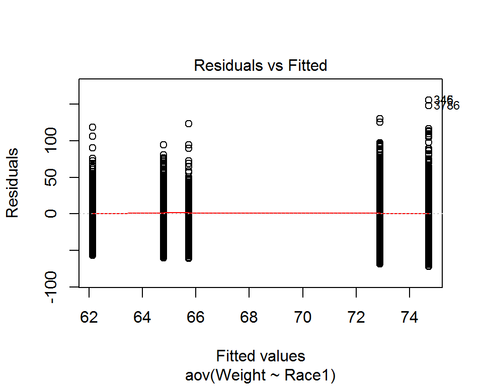

```r
plot(race.aov, 1)
```

# Gender, Race, and BMI

This code will let us view the distribution of the residuals to assess normality.

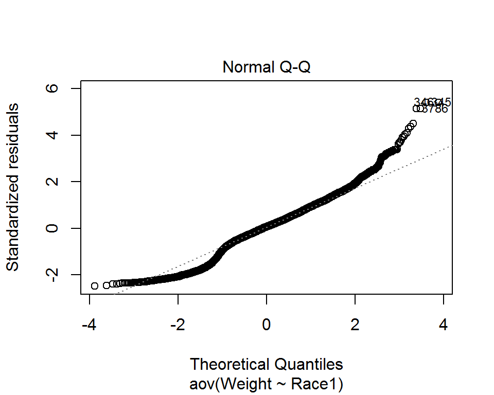

```r
plot(race.aov, 2)
```

# Gender, Race, and BMI

We can statistically test whether we have normality in the residuals. However, these tests are generally poor approximations.

# Gender, Race, and BMI

Let’s look at the output

```r
summary(race.aov)
```

```
##               Df  Sum Sq Mean Sq F value Pr(>F)
## Race1          4  157850   39462   47.39 <2e-16 ***
## Residuals   9917 8258000     833
## ---
## Signif. codes:  0 '***' 0.001 '**' 0.01 '*' 0.05 '.' 0.1 ' ' 1
## 78 observations deleted due to missingness
```

# Post-Hoc tests

Post-hoc tests allow us to identify where the differences lie when we have a significant F-test. There are numerous tests out there. Some are very good, some not so good. All of them do multiple pairwise comparisons (multiple T-tests). All of them *penalize* our $\alpha$ level, so that the overall $\alpha = 0.05$ but individual pairwise comparisons require a much smaller p-value to indicate significance.

# Gender, Race, and BMI

We will use Tukey’s Honestly Significant Difference test (HSD)

```r
TukeyHSD(race.aov, which = "Race1")
```

```
##   Tukey multiple comparisons of means
##     95% family-wise confidence level
##
## Fit: aov(formula = Weight ~ Race1, data = NHANES)
##
## $Race1
##                         diff        lwr        upr     p adj
## Hispanic-Black    -8.9907103 -12.912709 -5.0687119 0.0000000
## Mexican-Black     -9.9292888 -13.299669 -6.5589085 0.0000000
## White-Black       -1.8248406  -4.311964  0.6622832 0.2651030
## Other-Black      -12.5903431 -16.189249 -8.9914376 0.0000000
## Mexican-Hispanic  -0.9385786  -4.979989  3.1028321 0.9696346
## White-Hispanic     7.1658697   3.825313 10.5064267 0.0000000
## Other-Hispanic    -3.5996328  -7.833503  0.6342374 0.1386748
## White-Mexican      8.1044482   5.432985 10.7759110 0.0000000
## Other-Mexican     -2.6610542  -6.389734  1.0676250 0.2924733
## Other-White      -10.7655025 -13.720053 -7.8109517 0.0000000
```

# Gender, Race, and BMI

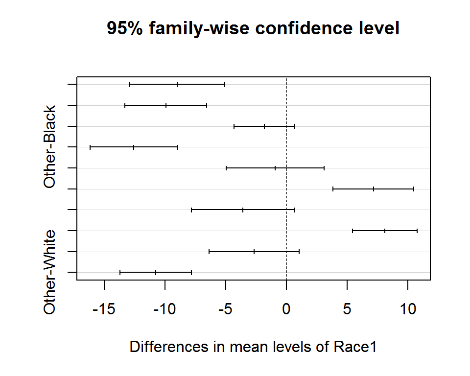

```r
plot(TukeyHSD(race.aov, which = "Race1"))
```

# A Two-Way ANOVA

We can also assess whether weight differs by Race **and** Gender. The general form is:

$\hat{Weight}_{ijk} = \mu + {Race}_i + {Gender}_j + {Race*Gender}_{ij} + \epsilon_k$

# A Two-Way ANOVA

```r
twoway.aov <- aov(Weight ~ Race1*Gender, data = NHANES)
```

# Assess assumptions

Homoscedasticity:

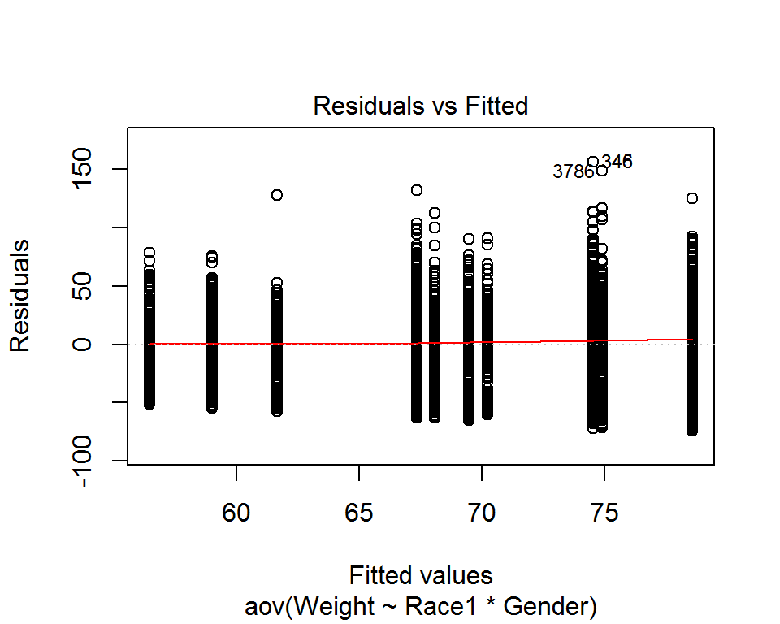

```r
plot(twoway.aov, 1)
```

# Assess assumptions

Normality:

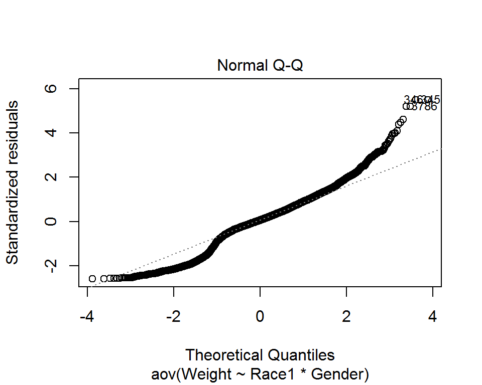

```r
plot(twoway.aov, 2)
```

# View model

```r
summary(twoway.aov)
```

```
##                Df  Sum Sq Mean Sq F value   Pr(>F)
## Race1           4  157850   39462  48.934  < 2e-16 ***
## Gender          1  233853  233853 289.983  < 2e-16 ***
## Race1:Gender    4   30760    7690   9.536 1.08e-07 ***
## Residuals    9912 7993387     806
## ---
## Signif. codes:  0 '***' 0.001 '**' 0.01 '*' 0.05 '.' 0.1 ' ' 1
## 78 observations deleted due to missingness
```

# Post-Hoc Testing

```r
TukeyHSD(twoway.aov, which = "Race1:Gender")
```

```
##   Tukey multiple comparisons of means
##     95% family-wise confidence level
##
## Fit: aov(formula = Weight ~ Race1 * Gender, data = NHANES)
##
## $`Race1:Gender`
##                                       diff          lwr         upr
## Hispanic:female-Black:female   -12.9028542 -19.11190226  -6.6938062
## Mexican:female-Black:female    -15.5262732 -21.11045030  -9.9420961
## White:female-Black:female       -7.2067331 -11.17761639  -3.2358499
## Other:female-Black:female      -18.0988633 -23.84185174 -12.3558748
## Black:male-Black:female          0.3574261  -4.85188527   5.5667376
## Hispanic:male-Black:female      -4.3211928 -10.73084935   2.0884638
## Mexican:male-Black:female       -5.0922601 -10.35873881   0.1742187
## White:male-Black:female          4.0285356   0.05062053   8.0064507
## Other:male-Black:female         -6.4714838 -12.29306776  -0.6498998
## Mexican:female-Hispanic:female  -2.6234190  -9.20058792   3.9537499
## White:female-Hispanic:female     5.6961211   0.41937672  10.9728654
## Other:female-Hispanic:female    -5.1960091 -11.90853718   1.5165190
## Black:male-Hispanic:female      13.2602804   6.99824853  19.5223122
## Hispanic:male-Hispanic:female    8.5816614   1.29058370  15.8727392
## Mexican:male-Hispanic:female     7.8105941   1.50092573  14.1202626
## White:male-Hispanic:female      16.9313898  11.64935181  22.2134278
## Other:male-Hispanic:female       6.4313704  -0.34852317  13.2112640
## White:female-Mexican:female      8.3195401   3.79463270  12.8444475
## Other:female-Mexican:female     -2.5725901  -8.71170966   3.5665295
## Black:male-Mexican:female       15.8836994  10.24066841  21.5267303
## Hispanic:male-Mexican:female    11.2050805   4.43820744  17.9719535
## Mexican:male-Mexican:female     10.4340132   4.73816631  16.1298600
## White:male-Mexican:female       19.5548088  15.02372934  24.0858883
## Other:male-Mexican:female        9.0547894   2.84208367  15.2674952
## Other:female-White:female      -10.8921302 -15.61162905  -6.1726313
## Black:male-White:female          7.5641593   3.51092862  11.6173899
## Hispanic:male-White:female       2.8855404  -2.62585246   8.3969332
## Mexican:male-White:female        2.1144731  -2.01197235   6.2409185
## White:male-White:female         11.2352687   8.97350797  13.4970295
## Other:male-White:female          0.7352493  -4.07958122   5.5500799
## Black:male-Other:female         18.4562894  12.65605829  24.2565206
## Hispanic:male-Other:female      13.7776705   6.87915957  20.6761815
## Mexican:male-Other:female       13.0066032   7.15497488  18.8582316
```

[output cut: 43 more lines]

```
## Black:male-Other:female        0.0000000
## Hispanic:male-Other:female     0.0000000
## Mexican:male-Other:female      0.0000000
## White:male-Other:female        0.0000000
## Other:male-Other:female        0.0000003
## Hispanic:male-Black:male       0.3945495
## Mexican:male-Black:male        0.0401394
## White:male-Black:male          0.1167957
## Other:male-Black:male          0.0090003
## Mexican:male-Hispanic:male     0.9999976
## White:male-Hispanic:male       0.0000739
## Other:male-Hispanic:male       0.9935314
## White:male-Mexican:male        0.0000000
## Other:male-Mexican:male        0.9992791
## Other:male-White:male          0.0000000
```

# Post-Hoc Testing

```r
lsmeans(twoway.aov, pairwise ~ Race1|Gender)[1]
```

```
## $lsmeans
## Gender = female:
##  Race1      lsmean        SE   df lower.CL upper.CL
##  Black    74.54361 1.1497935 9912 72.28978 76.79744
##  Hispanic 61.64075 1.5899719 9912 58.52408 64.75742
##  Mexican  59.01733 1.3386854 9912 56.39324 61.64143
##  White    67.33687 0.5026357 9912 66.35161 68.32214
##  Other    56.44474 1.4041811 9912 53.69226 59.19722
##
## Gender = male:
##  Race1      lsmean        SE   df lower.CL upper.CL
##  Black    74.90103 1.1781395 9912 72.59164 77.21043
##  Hispanic 70.22241 1.6675766 9912 66.95362 73.49120
##  Mexican  69.45135 1.2032536 9912 67.09272 71.80997
##  White    78.57214 0.5081580 9912 77.57605 79.56824
##  Other    68.07212 1.4361388 9912 65.25700 70.88725
##
## Confidence level used: 0.95
```

# Post-Hoc Testing

```r
lsmeans(twoway.aov, pairwise ~ Race1|Gender)[2]
```

```
## $contrasts
## Gender = female:
##  contrast             estimate       SE   df t.ratio p.value
##  Black - Hispanic   12.9028542 1.962151 9912   6.576  <.0001
##  Black - Mexican    15.5262732 1.764682 9912   8.798  <.0001
##  Black - White       7.2067331 1.254858 9912   5.743  <.0001
##  Black - Other      18.0988633 1.814869 9912   9.973  <.0001
##  Hispanic - Mexican  2.6234190 2.078482 9912   1.262  0.7145
##  Hispanic - White   -5.6961211 1.667529 9912  -3.416  0.0058
##  Hispanic - Other    5.1960091 2.121258 9912   2.449  0.1025
##  Mexican - White    -8.3195401 1.429938 9912  -5.818  <.0001
##  Mexican - Other     2.5725901 1.940052 9912   1.326  0.6749
##  White - Other      10.8921302 1.491431 9912   7.303  <.0001
##
## Gender = male:
##  contrast             estimate       SE   df t.ratio p.value
##  Black - Hispanic    4.6786189 2.041770 9912   2.291  0.1476
##  Black - Mexican     5.4496862 1.683993 9912   3.236  0.0107
##  Black - White      -3.6711095 1.283058 9912  -2.861  0.0344
##  Black - Other       6.8289099 1.857554 9912   3.676  0.0022
##  Hispanic - Mexican  0.7710673 2.056364 9912   0.375  0.9958
##  Hispanic - White   -8.3497284 1.743283 9912  -4.790  <.0001
##  Hispanic - Other    2.1502910 2.200751 9912   0.977  0.8657
##  Mexican - White    -9.1207957 1.306156 9912  -6.983  <.0001
##  Mexican - Other     1.3792237 1.873583 9912   0.736  0.9481
##  White - Other      10.5000194 1.523391 9912   6.893  <.0001
##
## P value adjustment: tukey method for comparing a family of 5 estimates
```

# Post-Hoc Testing

```r
lsmeans(twoway.aov, pairwise ~ Gender|Race1)[1]
```

```
## $lsmeans
## Race1 = Black:
##  Gender   lsmean        SE   df lower.CL upper.CL
##  female 74.54361 1.1497935 9912 72.28978 76.79744
##  male   74.90103 1.1781395 9912 72.59164 77.21043
##
## Race1 = Hispanic:
##  Gender   lsmean        SE   df lower.CL upper.CL
##  female 61.64075 1.5899719 9912 58.52408 64.75742
##  male   70.22241 1.6675766 9912 66.95362 73.49120
##
## Race1 = Mexican:
##  Gender   lsmean        SE   df lower.CL upper.CL
##  female 59.01733 1.3386854 9912 56.39324 61.64143
##  male   69.45135 1.2032536 9912 67.09272 71.80997
##
## Race1 = White:
##  Gender   lsmean        SE   df lower.CL upper.CL
##  female 67.33687 0.5026357 9912 66.35161 68.32214
##  male   78.57214 0.5081580 9912 77.57605 79.56824
##
## Race1 = Other:
##  Gender   lsmean        SE   df lower.CL upper.CL
##  female 56.44474 1.4041811 9912 53.69226 59.19722
##  male   68.07212 1.4361388 9912 65.25700 70.88725
##
## Confidence level used: 0.95
```

# Post-Hoc Testing

```r
lsmeans(twoway.aov, pairwise ~ Gender|Race1)[2]
```

```
## $contrasts
## Race1 = Black:
##  contrast         estimate        SE   df t.ratio p.value
##  female - male  -0.3574261 1.6462193 9912  -0.217  0.8281
##
## Race1 = Hispanic:
##  contrast         estimate        SE   df t.ratio p.value
##  female - male  -8.5816614 2.3040881 9912  -3.725  0.0002
##
## Race1 = Mexican:
##  contrast         estimate        SE   df t.ratio p.value
##  female - male -10.4340132 1.7999716 9912  -5.797  <.0001
##
## Race1 = White:
##  contrast         estimate        SE   df t.ratio p.value
##  female - male -11.2352687 0.7147498 9912 -15.719  <.0001
##
## Race1 = Other:
##  contrast         estimate        SE   df t.ratio p.value
##  female - male -11.6273795 2.0085366 9912  -5.789  <.0001
```

# Plot our interactions

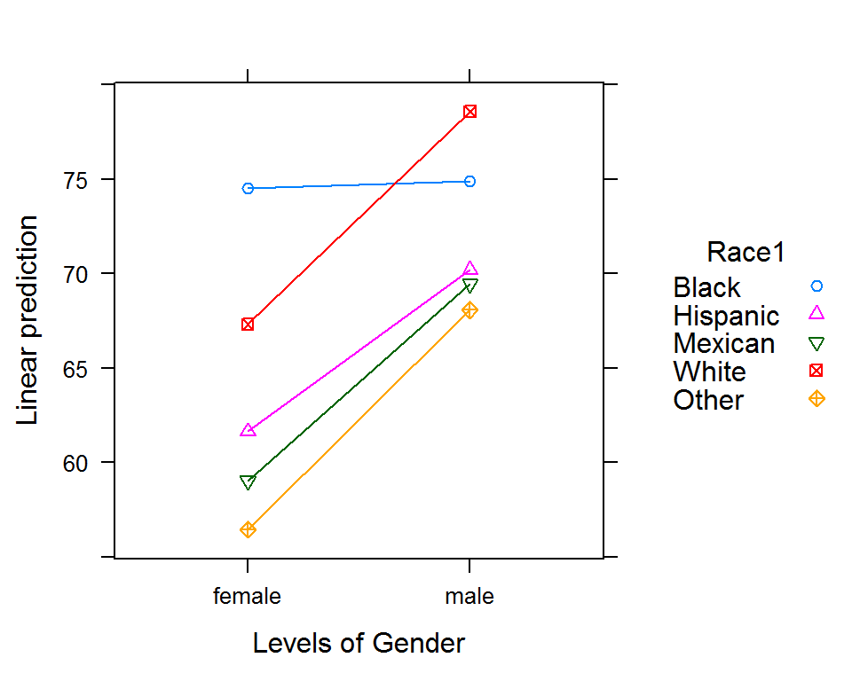

```r
lsmip(lsmeans(twoway.aov, ~ Gender|Race1), Race1 ~ Gender)
```

# Plot our interactions

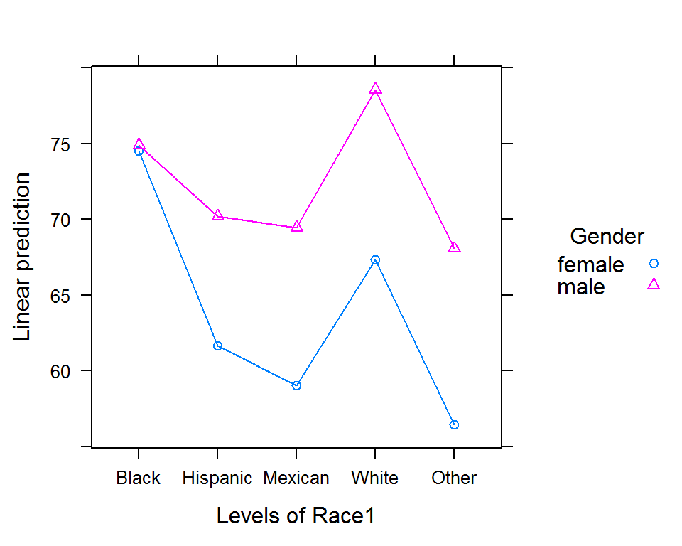

```r
lsmip(lsmeans(twoway.aov, ~ Race1|Gender), Gender ~ Race1)
```